# 303.1. Galaxy photometry in DP2

For the Rubin Science Platform at data.lsst.cloud.  
Data Release: [Data Preview 2](https://dp2.lsst.io/)  
Container Size: Large  
LSST Science Pipelines version: r30.0.11  
Last verified to run: 2026-09-04  
Repository: github.com/lsst/tutorial-notebooks  
DOI: 10.11578/rubin/dc.20250909.20

**Learning objective:** Explore the available measurements of galaxy photometry produced by the LSST pipelines and their applications.

**LSST data products:** `Object` table

**Packages:** `lsst.rsp`

**Credit:** Originally developed by the Rubin Community Science team. Please consider acknowledging them if this notebook is used for the preparation of journal articles, software releases, or other notebooks.

**Get Support:** Everyone is encouraged to ask questions or raise issues in the [Support Category](https://community.lsst.org/c/support) of the Rubin Community Forum. Rubin staff will respond to all questions posted there.

## 1. Introduction

Photometry is the measurement of how much light is apparent from astronomical sources. The amount of light arriving on the telescope from the object is typically referred to as the flux density, or apparent magnitude (depending on units). Flux density is defined as the amount of energy arriving on the telescope per unit area, per unit time, per unit frequency (or wavelength) of the light.

The LSST Science Pipelines makes a variety of photometric measurements for point-like and extended sources. This notebook will teach the user about the automated photometry measurements for extended sources that are measured on the `deep_coadd` images and appear in the `object` table as part of the LSST pipelines data products.

The photometry measurements in the catalogs are flux densities in units of nano-Jansky [nJy]. 1 Jy = 10^{-23} ergs/s/cm^2/Hz.

### 1.1. Import packages

Import `numpy`, a fundamental package for scientific computing with arrays in Python (numpy.org), and `matplotlib`, a comprehensive library for data visualization ([matplotlib.org](https://matplotlib.org/); [matplotlib gallery](https://matplotlib.org/stable/gallery/index.html)).

From the `lsst` package, import the `RSPDiscovery` module for accessing the Table Access Protocol (TAP) service.

Finally, import `scipy.stats` package.

```python
import numpy as np
import matplotlib.pyplot as plt
from lsst.rsp import RSPDiscovery
from scipy.stats import binned_statistic
```

### 1.2. Define parameters and functions

```python
discovery = RSPDiscovery("dp2")
service = discovery.get_tap_client()
```

Define parameters to use colorblind-friendly colors with `matplotlib`.

```python
plt.style.use('seaborn-v0_8-colorblind')
prop_cycle = plt.rcParams['axes.prop_cycle']
colors = prop_cycle.by_key()['color']
```

## 2. Types of photometry

This section will explore photometry measurements produced by the LSST pipelines, and provide some guidance for which are optimal for various applications for science with galaxies.

### 2.1. Explore the schema

Numerous photometry measurements are produced by the LSST Pipelines. Two types of photometry are in the `object` table. The first are total fluxes (see Section 3), which aim to approximate (or model) all of the light coming from object. The second class of fluxes are measured inside an on-sky aperture but not corrected for flux that may fall outside: thus they are apparent fluxes but do not recover the intrisic (total) flux (see Section 4 and 5). The apparent fluxes are optimized for other purposes, such as for measuring accurate light profiles or accurate colors.

Descriptions for all the measurements in the `object` table can be found in the [DP2 schema](https://sdm-schemas.lsst.io/dp2.html); the schema can also be obtained programmatically as demonstrated in the following code cells.

First, see what is available in the object table by querying the `tap_schema` columns, and printing all the parameters available related to "Flux" measured in the i-band (as an example). For clarity, the return also omits errors and flags associated with the photometric measurements outlined in section 1.1.

```python
query = "SELECT column_name, datatype, description, unit " \
        "FROM tap_schema.columns " \
        "WHERE table_name = 'dp2.Object'"
results = service.search(query).to_table()
```

```python
search_string = 'Flux'
band = 'i_'
exclude1 = 'Err'
exclude2 = 'flag'
for cname in results['column_name']:
    if cname.find(search_string) > -1 and cname.find(band) > -1 and \
       cname.find(exclude1) == -1 and cname.find(exclude2) == -1:
        print(cname)
```

```
i_psfFlux
i_free_psfFlux
i_cModel_devFlux
i_cModel_expFlux
i_gaapPsfFlux
i_gaap0p7Flux
i_gaap1p0Flux
i_kronFlux
i_ap03Flux
i_ap06Flux
i_ap09Flux
i_ap12Flux
i_ap17Flux
i_ap25Flux
i_ap35Flux
i_ap50Flux
i_ap70Flux
i_cModelFlux
i_cModelFlux_inner
i_free_cModelFlux
i_free_cModelFlux_inner
i_free_cModel_devFlux
i_free_cModel_expFlux
i_deblend_zeroFlux
i_psfFlux_area
i_exponentialFlux
i_sersicFlux
```

The object catalog also has pre-computed AB magnitudes (`Mag` columns) for `cModel` and `psf` fluxes. Query the `tap_schema` columns, and print all the parameters available related to `Mag` measured in the i-band.

```python
search_string = 'Mag'
band = 'i_'
exclude1 = 'Err'
for cname in results['column_name']:
    if cname.find(search_string) > -1 and cname.find(band) > -1 and \
       cname.find(exclude1) == -1:

        print(cname)
```

```
i_psfMag
i_cModelMag
```

### 2.2. Select a galaxy sample

Query the DP2 `object` table for a selection of photometric measurements.

Limit the search to contain galaxies using the `i_extendedness` flag. This will exclude many point-like objects, but not all. While some contamination by point-like objects is tolerable for the purposes of this demonstration, users should consider the variety of extendedness measurements when deciding how to constrain samples for scientific analysis (see, e.g., the [flag usage guidance](https://dp2.lsst.io/products/flags/index.html)).

Further, identify objects which have been detected at high signal to noise > 20 and whose photometric measurements have not been flagged as having an issue (`i_kronFlux_flag` or `i_cModel_flag` or `sersic_no_data_flag` = 0 means the photometry is ok). Also exclude very bright galaxies (i-band magnitude < 20).

Search for the sample using the DP2 imaging obtained in the Extended Chandra Deep Field South (ECDFS; center ra, dec = 53.2, -28.1 in degrees).

```python
target_ra = 53.2
target_dec = -28.1
query = "SELECT obj.objectId, obj.coord_ra, obj.coord_dec, " + \
        "obj.detect_fromBlend, obj.detect_isIsolated, " + \
        "obj.i_blendedness, obj.i_extendedness, " + \
        "obj.i_kronFlux, obj.i_kronFluxErr, obj.i_kronRad, " + \
        "obj.i_cModelFlux, obj.i_cModelFluxErr, " + \
        "obj.i_cModel_devFlux, obj.i_cModel_expFlux, obj.i_cModel_fracDev, " + \
        "obj.i_gaap1p0Flux, obj.r_gaap1p0Flux, " + \
        "obj.sersic_index, " + \
        "obj.i_sersicFlux, obj.i_exponentialFlux, " + \
        "obj.i_kronFlux_flag, obj.i_cModel_flag, obj.sersic_no_data_flag, " + \
        "obj.i_ap03Flux, obj.i_ap06Flux, obj.i_ap09Flux, obj.i_ap12Flux, " + \
        "obj.i_ap17Flux, obj.i_ap25Flux, obj.i_ap35Flux, obj.i_ap50Flux " + \
        "FROM dp2.Object AS obj " + \
        "WHERE (obj.i_cModelFlux/obj.i_cModelFluxErr > 20) AND " + \
        "(obj.i_extendedness = 1) AND (obj.sersic_no_data_flag = 0) AND " + \
        "(obj.i_kronFlux_flag = 0) AND (obj.i_cModel_flag = 0) AND " + \
        "(scisql_nanojanskyToAbMag(obj.i_cModelFlux) > 20) AND " + \
        "CONTAINS(POINT('ICRS', obj.coord_ra, obj.coord_dec), " + \
        "CIRCLE('ICRS',"+str(target_ra)+","+str(target_dec)+", 0.1)) = 1 "
```

```python
job = service.submit_job(query)
job.run()
job.wait(phases=['COMPLETED', 'ERROR'])
print('Job phase is', job.phase)
if job.phase == 'ERROR':
    job.raise_if_error()
assert job.phase == 'COMPLETED'
tab = job.fetch_result().to_table()
```

```
Job phase is COMPLETED
```

Print the results of the search query.

```python
tab
```

*Table length=2448*

| objectId int64 | coord_ra deg float64 | coord_dec deg float64 | detect_fromBlend bool | detect_isIsolated bool | i_blendedness float32 | i_extendedness float32 | i_kronFlux nJy float32 | i_kronFluxErr nJy float32 | i_kronRad pix float32 | i_cModelFlux nJy float32 | i_cModelFluxErr nJy float32 | i_cModel_devFlux nJy float32 | i_cModel_expFlux nJy float32 | i_cModel_fracDev float32 | i_gaap1p0Flux nJy float32 | r_gaap1p0Flux nJy float32 | sersic_index float32 | i_sersicFlux nJy float32 | i_exponentialFlux nJy float32 | i_kronFlux_flag bool | i_cModel_flag bool | sersic_no_data_flag bool | i_ap03Flux nJy float32 | i_ap06Flux nJy float32 | i_ap09Flux nJy float32 | i_ap12Flux nJy float32 | i_ap17Flux nJy float32 | i_ap25Flux nJy float32 | i_ap35Flux nJy float32 | … |
| --- | --- | --- | --- | --- | --- | --- | --- | --- | --- | --- | --- | --- | --- | --- | --- | --- | --- | --- | --- | --- | --- | --- | --- | --- | --- | --- | --- | --- | --- | --- |
| 755369504803917291 | 53.29995352431074 | -28.0547425924061 | False | True | 0.0 | 1.0 | 1414.72 | 72.0451 | 4.94271 | 1403.65 | 38.7482 | 1647.6 | 1409.58 | 0.0 | 1150.62 | 803.32 | 0.998802 | 1405.98 | 1405.63 | False | False | False | 486.864 | 1016.58 | 1320.04 | 1336.43 | 1356.0 | 1537.43 | 2091.29 | … |
| 755369504803917615 | 53.27852121568102 | -28.041728904182452 | False | True | 0.0 | 1.0 | 3233.27 | 57.1106 | 3.88724 | 3356.16 | 37.6656 | 3742.26 | 3369.76 | 0.0 | 2883.62 | 2008.29 | 0.560724 | 3277.18 | 3333.87 | False | False | False | 1234.44 | 2631.58 | 3077.74 | 3254.31 | 3200.47 | 3216.93 | 3563.03 | … |
| 755369504803917532 | 53.293283291734404 | -28.04488854033139 | False | True | 0.0 | 1.0 | 2862.44 | 59.0203 | 4.03617 | 2737.52 | 32.9685 | 2807.54 | 2715.79 | 0.318602 | 2570.97 | 1629.27 | 1.37526 | 2725.83 | 2709.26 | False | False | False | 1244.24 | 2295.36 | 2630.83 | 2842.01 | 2848.95 | 2853.79 | 3625.39 | … |
| 755369504803917500 | 53.28234741164852 | -28.046407171944857 | False | True | 0.0 | 1.0 | 1322.73 | 67.146 | 4.42771 | 1232.63 | 32.7592 | 1264.39 | 1238.41 | 0.0 | 1182.68 | 559.705 | 1.0 | 1246.6 | 1246.6 | False | False | False | 589.831 | 1028.35 | 1232.82 | 1313.65 | 1401.64 | 1460.33 | 1725.96 | … |
| 755369504803917506 | 53.28618008377495 | -28.046274702255996 | False | True | 0.0 | 1.0 | 620.809 | 67.0139 | 4.51427 | 632.483 | 30.597 | 631.973 | 626.249 | 1.0 | 593.758 | 497.226 | 1.0 | 604.945 | 604.945 | False | False | False | 303.533 | 545.726 | 552.365 | 598.198 | 718.719 | 1037.21 | 1287.13 | … |
| 755369573523419082 | 53.11010031308377 | -28.056637623159684 | True | False | -2.78063 | 1.0 | 563.165 | 36.124 | 2.7085 | 624.258 | 29.8603 | 643.001 | 626.239 | 0.0 | 562.47 | 415.416 | 1.0 | 581.709 | 581.709 | False | False | False | 276.948 | 504.797 | 552.537 | 607.75 | 541.965 | 673.904 | 392.952 | … |
| 755369573523419084 | 53.27540362944091 | -28.056449925729464 | True | False | -4.2554 | 1.0 | 1029.83 | 52.9737 | 3.42355 | 1019.68 | 33.4041 | 1037.58 | 1022.55 | 0.0 | 981.126 | 727.301 | 1.0 | 1052.26 | 1049.51 | False | False | False | 486.334 | 878.368 | 999.324 | 997.932 | 1069.73 | 1203.73 | 1532.87 | … |
| 755369573523419086 | 53.264253287024864 | -28.05643489446994 | True | False | -7.21747 | 1.0 | 1302.45 | 227.223 | 14.5546 | 1166.24 | 33.0592 | 1176.58 | 1169.59 | 0.0 | 1093.95 | 658.694 | 1.0 | 1137.71 | 1137.71 | False | False | False | 562.651 | 1001.03 | 1065.43 | 986.574 | 992.808 | 1111.53 | 1216.97 | … |
| 755369573523419072 | 53.26825865443503 | -28.057639907755988 | True | False | -5.03204 | 1.0 | 1057.88 | 52.191 | 3.36517 | 1063.47 | 33.556 | 1062.44 | 1040.46 | 1.0 | 1007.23 | 806.643 | 1.0 | 1044.11 | 1044.11 | False | False | False | 511.261 | 897.725 | 1024.83 | 1054.55 | 1000.83 | 1126.17 | 1602.54 | … |
| ... | ... | ... | ... | ... | ... | ... | ... | ... | ... | ... | ... | ... | ... | ... | ... | ... | ... | ... | ... | ... | ... | ... | ... | ... | ... | ... | ... | ... | ... | … |
| 755368886328627624 | 53.210566565711 | -28.188256343563943 | False | True | 0.0 | 1.0 | 816.844 | 69.6818 | 4.47262 | 814.582 | 36.89 | 866.124 | 781.559 | 0.429168 | 723.926 | 641.206 | 1.0 | 754.747 | 754.747 | False | False | False | 344.887 | 639.556 | 777.827 | 780.634 | 811.567 | 1026.0 | 1290.44 | … |
| 755368886328627633 | 53.2346745806509 | -28.18745262077458 | False | True | 0.0 | 1.0 | 8953.93 | 73.7362 | 4.68576 | 8822.35 | 42.4398 | 11111.3 | 8857.92 | 0.0 | 7263.55 | 3894.11 | 0.858384 | 8806.48 | 8903.12 | False | False | False | 3123.0 | 6690.56 | 8248.61 | 8671.76 | 8923.72 | 9156.67 | 9125.59 | … |
| 755368886328627643 | 53.17988648404575 | -28.187288276715655 | False | True | 0.0 | 1.0 | 4999.43 | 95.9461 | 6.08847 | 5586.85 | 65.5502 | 7906.7 | 5007.96 | 0.285344 | 3079.07 | 2655.66 | 1.0356 | 5040.16 | 5013.77 | False | False | False | 1070.05 | 2692.59 | 3902.09 | 4609.6 | 4800.91 | 4786.93 | 5343.2 | … |
| 755368886328627476 | 53.20910825829933 | -28.19454588576937 | False | True | 0.0 | 1.0 | 864.557 | 57.0972 | 3.69539 | 797.156 | 33.3584 | 814.509 | 793.016 | 0.307192 | 768.142 | 416.252 | 1.0 | 752.568 | 752.568 | False | False | False | 386.161 | 671.055 | 834.975 | 854.457 | 941.633 | 1005.54 | 1425.33 | … |
| 755368886328627524 | 53.20838526719028 | -28.192398129060187 | False | True | 0.0 | 1.0 | 2095.75 | 69.2284 | 4.45958 | 2127.89 | 37.5518 | 2350.58 | 2137.45 | 0.0 | 1845.79 | 1228.81 | 0.574232 | 2079.57 | 2106.74 | False | False | False | 842.635 | 1709.91 | 1933.09 | 2024.0 | 2097.3 | 2204.54 | 2447.99 | … |
| 755368886328627515 | 53.211117287822674 | -28.192754826530244 | False | True | 0.0 | 1.0 | 4278.46 | 80.579 | 5.15763 | 4399.4 | 53.8613 | 6290.01 | 4415.84 | 0.0 | 2780.08 | 973.613 | 0.505871 | 4165.57 | 4405.97 | False | False | False | 952.226 | 2484.3 | 3501.72 | 3958.39 | 4215.32 | 4356.83 | 4528.19 | … |
| 755368886328627522 | 53.21756223930313 | -28.192313405372573 | False | True | 0.0 | 1.0 | 2620.04 | 79.9185 | 5.08378 | 2674.47 | 51.7611 | 3803.18 | 2684.46 | 0.0 | 1824.85 | 808.034 | 0.592978 | 2613.27 | 2754.99 | False | False | False | 663.561 | 1650.63 | 2208.42 | 2482.83 | 2528.47 | 2781.84 | 3291.19 | … |
| 755369642242894084 | 53.086708739954794 | -28.10107353300232 | True | False | -4.20846 | 1.0 | 1536.13 | 82.0766 | 5.477 | 1379.96 | 39.023 | 1452.1 | 1290.84 | 0.58103 | 1160.57 | 902.409 | 1.63947 | 1294.6 | 1268.82 | False | False | False | 508.727 | 1012.82 | 1253.1 | 1435.79 | 1450.24 | 1669.58 | 2068.82 | … |
| 755369642242894228 | 53.086865385546545 | -28.098331173104896 | True | False | -28.6942 | 1.0 | 7911.47 | 69.861 | 4.63945 | 7865.07 | 41.0404 | 9612.65 | 7877.11 | 0.0 | 6601.18 | 3083.45 | 0.788995 | 7831.06 | 7941.01 | False | False | False | 2716.71 | 5977.5 | 7327.75 | 7666.57 | 7839.84 | 7984.3 | 8270.61 | … |

Below, convert the fluxes (units $nJy$) extracted from the `object` table into AB magnitudes using: $m_{AB} = -2.5log( f_{nJy}) + 31.4$ (see e.g. [AB Magnitudes Wikipedia page](https://en.wikipedia.org/wiki/AB_magnitude) for the conversion between flux in Jy and AB magnitudes).

> **Warning:** The following cell will produce warnings for invalid value encountered in log10, which happens if the source flux is negative. This occasionally happens from aperture photometry if the included pixels inside the aperture have negative values and can be safely ignored for this example. The log10 will return a NaN which can be filtered out later.

```python
cmodel_mag = -2.50 * np.log10(tab['i_cModelFlux']) + 31.4
sersic_mag = -2.50 * np.log10(tab['i_sersicFlux']) + 31.4
cmodel_exp_mag = -2.50 * np.log10(tab['i_cModel_expFlux']) + 31.4
cmodel_dev_mag = -2.50 * np.log10(tab['i_cModel_devFlux']) + 31.4
exponential_mag = -2.50 * np.log10(tab['i_exponentialFlux']) + 31.4
ap06_mag = -2.50 * np.log10(tab['i_ap06Flux']) + 31.4
ap09_mag = -2.50 * np.log10(tab['i_ap09Flux']) + 31.4
ap17_mag = -2.50 * np.log10(tab['i_ap17Flux']) + 31.4
ap12_mag = -2.50 * np.log10(tab['i_ap12Flux']) + 31.4
ap35_mag = -2.50 * np.log10(tab['i_ap35Flux']) + 31.4
kron_mag = -2.50 * np.log10(tab['i_kronFlux']) + 31.4
gaap_mag = -2.50 * np.log10(tab['i_gaap1p0Flux']) + 31.4
```

```
/tmp/ipykernel_1047/3036620627.py:10: RuntimeWarning: invalid value encountered in log10
  ap35_mag = -2.50 * np.log10(tab['i_ap35Flux']) + 31.4
/tmp/ipykernel_1047/3036620627.py:11: RuntimeWarning: invalid value encountered in log10
  kron_mag = -2.50 * np.log10(tab['i_kronFlux']) + 31.4
```

## 3. Total fluxes

The following total flux measurements are available for galaxies from entries in the `object` table: total fluxes from a Sersic model (with shape parameters left free), from `cModel` (sum of bulge and disk Sersic components fitted to the galaxy); and bulge (de Vaucouleurs) and/or exponential disk fluxes (with Sersic index fixed to either n=4 or 1).

##### Sersic fluxes

This photometric measurement models all galaxies as a single Sersic profile and calculates its total flux according to the best fitting model. See the [Sersic profile Wikipedia page](https://en.wikipedia.org/wiki/S%C3%A9rsic_profile) for more information.

The best fit Sersic model is evaluated based on a model to all filters, and then the flux in each filter is calculated by integrating the galaxy light from the best fit model, assuming the best-fit Sersic shape parameters.

```
<f>_sersicFlux    : Flux from the final sersic fit. Forced on <f>-band.
<f>_sersicFluxErr : Uncertainty of <f>_sersicFlux
sersic_no_data_flag   : Failure flag for <f>_sersicFlux
```

The LSST pipeline package responsible for `Sersic` fluxes is called `multiprofit`. [Visit the multiprofit documentation](https://pipelines.lsst.io/modules/lsst.multiprofit/index.html#module-lsst.multiprofit).

##### Exponential fluxes

This photometric measurement models all galaxies as a single Sersic profile with Sersic index n fixed to 1 (exponential disk) and calculates its total flux according to the best fitting model. See the [Sersic profile Wikipedia page](https://en.wikipedia.org/wiki/S%C3%A9rsic_profile) for more information.

The best fit exponential model is evaluated based on a model to all filters, and then the flux in each filter is calculated by integrating the galaxy light from the best fit model, assuming the best-fit Sersic shape parameters when n is fixed to 1.

```
<f>_exponentialFlux    : Flux from the final Sersic fit assuming n=1. Forced on <f>-band.
<f>_exponentialFluxErr : Uncertainty of <f>_exponentialFlux
```

##### Composite Model (CModel) fluxes

Similar in nature to the [SDSS cModel photometry](https://www.sdss3.org/dr8/algorithms/magnitudes.php#cmodel), these will be familiar to SDSS users. In short, it is the linear combination of the best fit exponential (disk or D; Sersic index n = 1) and de Vaucouleurs (bulge or B; Sersic index n = 4) profiles. Thus, `cModel` is a good compromise between the exponential fluxes that assume either a disk (n=1) or a bulge (n=4).

```
<f>_cModelFlux    : Flux from the final cmodel fit. Forced on <f>-band.
<f>_cModelFluxErr : Uncertainty of <f>_cModelFlux
<f>_cModel_flag   : Failure flag for <f>_cModelFlux
```

For most cases the "fixed" `cModel` photometry (i.e. the catalog entries listed above) are preferred to that measured with more degrees of freedom labeled `<f>_free_cModelFlux`. The difference is that the fixed ones above uses a reference band (recorded as `refBand` in the schema) where the galaxy is well detected to determine the other parameters, which are then fixed when fitting for the flux in the other bands. The `_free_cModelFlux` measurement allows all parameters to be free and independent in each filter. The fixed `_cModelFlux` measurements are generally recommended for galaxy science applications where total flux measurements are needed (e.g. for intrinsic luminosity or mass).

In the `object` table, a pre-computed AB magnitude (`<f>_cModelMag`) also exists for this measurement.

##### Exponential disk fluxes (assuming n=1)

These fluxes assume an exponential profile, and is measured on the reference band with a fixed n=1 Sersic index, using the `meas_modelfit` package. It is run as an initialization for the `cModel` output.

```
<f>_cModel_expFlux    : Flux from the cmodel fit with n=1. Forced on <f>-band.
<f>_cModel_expFluxErr : Uncertainty of <f>_cModel_expFlux
```

##### De Vaucouleurs bulge fluxes (assuming n=4)

These fluxes assume an de Vaucouleurs profile, and is measured on the reference band with a fixed n=4 Sersic index, using the `meas_modelfit` package. It is run as an initialization for the `cModel` output.

```
<f>_cModel_devFlux    : Flux from the cmodel fit with n=4. Forced on <f>-band.
<f>_cModel_devFluxErr : Uncertainty of <f>_cModel_devFlux
```

Below, store the bulge and disc components of the `cModel` 2-Sersic-component flux. These were previously stored in the DP1 schema as bdFluxB (bulge, or n=4) and bdFluxD (disk, or n=1), but are deprecated in DP2. They can be reconstructed using the `i_cModel_fracDev` value, which holds the fraction of the `cModel` flux from the de Vaucouleurs (n=4) component, to decompose.

```python
tab['i_bdFluxB'] = tab['i_cModelFlux'] * tab['i_cModel_fracDev']
tab['i_bdFluxD'] = tab['i_cModelFlux'] * (1 - tab['i_cModel_fracDev'])
bdFluxD_mag = -2.50 * np.log10(tab['i_bdFluxD']) + 31.4
bdFluxB_mag = -2.50 * np.log10(tab['i_bdFluxB']) + 31.4
```

### 3.1. Comparing total fluxes

This section will make several plots that show how the different photometric measurements compare.

First, compare `cModelFlux` (two component bulge+disk Sersic model flux) to `sersicFlux` (single Sersic model flux with shape parameters free), `cModel_devFlux` (Sersic with n=4) and `cModel_expFlux` (Sersic with n=1).

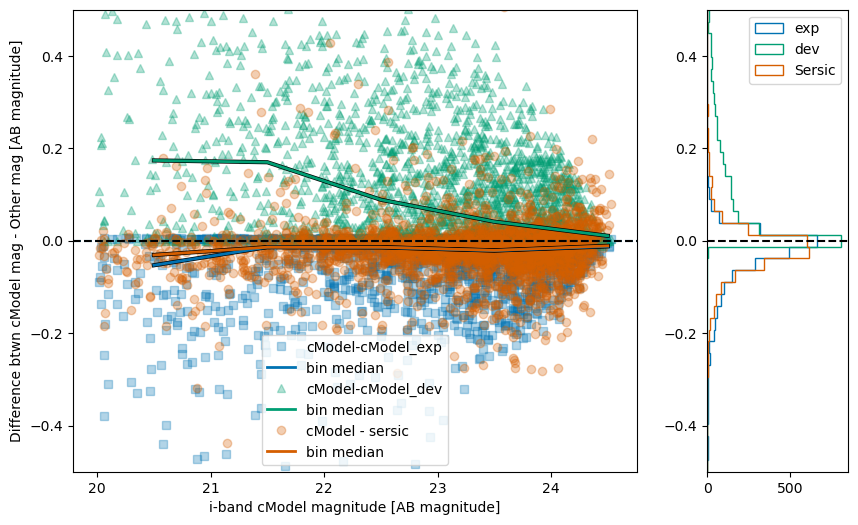

```python
fig, (ax, ax2) = plt.subplots(ncols=2, nrows=1,
                              width_ratios=[0.8, 0.2], figsize=(10, 6))

bins = np.arange(16, 27, 1)

ylims = [-0.5, 0.5]

ax.plot(cmodel_mag, (cmodel_mag-cmodel_exp_mag), 's', alpha=.3,
        label='cModel-cModel_exp', color=colors[0])
x = cmodel_mag
y = (cmodel_mag-exponential_mag)
bin_mean, bin_edge, binnum = binned_statistic(x, y,
                                              statistic='median', bins=bins)
binctr = bin_edge[:-1] + (bin_edge[1:]-bin_edge[:-1])/2
ax.plot(binctr, bin_mean, color='k', lw=3, label=None, zorder=10)
ax.plot(binctr, bin_mean, color=colors[0],
        lw=2, label='bin median', zorder=11)

ax.plot(cmodel_mag, (cmodel_mag-cmodel_dev_mag), '^', alpha=.3,
        label='cModel-cModel_dev', color=colors[1])
x = cmodel_mag
y = (cmodel_mag-cmodel_dev_mag)
bin_mean, bin_edge, binnum = binned_statistic(x, y,
                                              statistic='median', bins=bins)
binctr = bin_edge[:-1] + (bin_edge[1:]-bin_edge[:-1])/2
ax.plot(binctr, bin_mean, color='k', lw=3, label=None, zorder=10)
ax.plot(binctr, bin_mean, color=colors[1], lw=2, label='bin median', zorder=11)


ax.plot(cmodel_mag, (cmodel_mag - sersic_mag), 'o', alpha=.3,
        label='cModel - sersic', color=colors[2])

x = cmodel_mag
y = (cmodel_mag-sersic_mag)
bin_mean, bin_edge, binnum = binned_statistic(x, y,
                                              statistic='median', bins=bins)
binctr = bin_edge[:-1] + (bin_edge[1:]-bin_edge[:-1])/2
ax.plot(binctr, bin_mean, color='k', lw=3, label=None, zorder=10)
ax.plot(binctr, bin_mean, color=colors[2], lw=2, label='bin median', zorder=11)

ax.axhline(0, linestyle='--')
ax.set_xlabel('cModel Magnitude')
ax.set_ylabel('cModel mag - other mag')
ax.set_ylim([-1, 1])
ax.legend()

ax2.hist((cmodel_mag-exponential_mag), orientation="horizontal",
         bins=np.linspace(ylims[0], ylims[1], 40), align='mid',
         histtype="step", color=colors[0], stacked=True, fill=False, label='exp')
ax2.hist((cmodel_mag-cmodel_dev_mag), orientation="horizontal",
         bins=np.linspace(ylims[0], ylims[1], 40), align='mid',
         histtype="step", color=colors[1], stacked=True, fill=False, label='dev')
ax2.hist((cmodel_mag-sersic_mag), orientation="horizontal",
         bins=np.linspace(ylims[0], ylims[1], 40), align='mid',
         histtype="step", color=colors[2], stacked=True, fill=False, label='Sersic')

ax2.set_ylim(ylims)
ax2.axhline(0, linestyle='--', color='k')
ax.axhline(0, linestyle='--', color='k')
ax.set_xlabel('i-band cModel magnitude [AB magnitude]')
ax.set_ylabel('Difference btwn cModel mag - Other mag [AB magnitude]')
ax.set_ylim(ylims)

ax.legend()
ax2.legend()
```

> **Figure 1:** Left panel: comparison between `cModel` flux with three other total flux measurements: Sersic flux with Sersic index n left free (orange), `cModel_exp` flux with n fixed to 1 (exponential disk; blue) and `cModel_dev` with n fixed to 4 (de Vaucouleurs or bulge profile; green). Right panel: histogram of values where values near 0 indicate the measured values are comparable. Sersic and cModel fluxes are more comparable than with n=1 or 4 fixed which have more scatter and disagree more for brighter galaxies (which also tend to be larger on-sky).

### 3.2. Exponential disk fluxes

Two estimates of total flux based on modeling objects as exponential disks (Sersic model with Sersic index n = 1) are in the `object` table. They are calculated using different algorithms, but the plot below demonstrates that the fluxes are very similar.

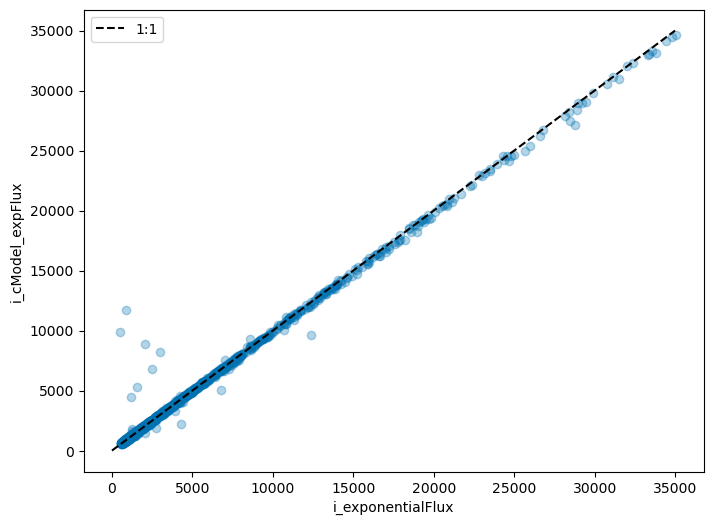

```python
fig, ax = plt.subplots(ncols=1, nrows=1, figsize=(8, 6))

one2one = np.arange(0, 35000, 1)

ax.plot(tab['i_exponentialFlux'], tab['i_cModel_expFlux'], 'o', alpha=.3)

ax.plot(one2one, one2one, linestyle='--', color='k', label='1:1')
ax.set_xlabel('i_exponentialFlux')
ax.set_ylabel('i_cModel_expFlux')
plt.legend()
```

> **Figure 2:** A comparison of the galaxy flux (modeled as an exponential disk with n=1) using the cModel algorithm (`cModel_expFlux`; y-axis) vs the multiprofit (`exponentialFlux`; x-axis). The results are very similar with little scatter indicating that the two methods provide similar fluxes. Note that Figure 1 shows that fixing the Sersic index to n=1 can underestimate the flux relative to the two component `cModelFlux` and the `sersicFlux` when the index is a free parameter, and may better agree with the actual light profile.

Below, compare the `cModelFlux` with the sum of its decomposed components (bulge and disk) that were calculated using the `cModel_devFrac` value stored in the `object` table.

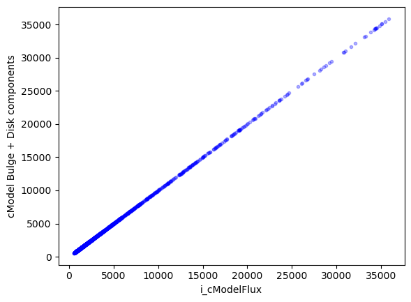

```python
plt.plot(tab['i_cModelFlux'], tab['i_bdFluxB'] + tab['i_bdFluxD'], '.', alpha=.3,
         color='blue')

plt.xlabel('i_cModelFlux')
plt.ylabel('cModel Bulge + Disk components')
```

> **Figure 3:** A comparison of the sum of the decomposed cModel bulge and disk components calculated using the `fracDev` parameter (y-axis) vs the composite `cModel` flux (x-axis) stored in the `object` table. The values are identical.

Below, store two shape parameters that will be useful for interpreting photometric apertures. First, the Kron Radius, which is a good proxy for the size of the galaxy light profile. Then, the Sersic index, which describes the shape of the light profile of galaxies.

```python
i_kronRad = tab['i_kronRad']
sersic_index = tab['sersic_index']
```

Plot a comparison of the flux measurements when sersic index is fixed, as a function of measured sersic index when sersic index is left free.

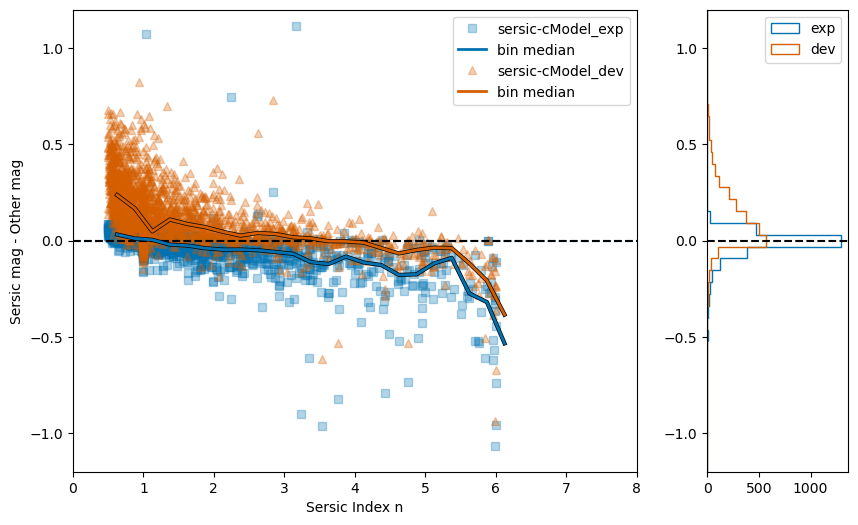

```python
fig, (ax, ax2) = plt.subplots(ncols=2, nrows=1,
                              width_ratios=[0.8, 0.2], figsize=(10, 6))

bins = np.arange(0, 7, 0.25)

ylims = [-1.2, 1.2]

ax.plot(sersic_index, (sersic_mag-cmodel_exp_mag), 's', alpha=.3,
        label='sersic-cModel_exp', color=colors[0])
x = sersic_index
y = (sersic_mag-cmodel_exp_mag)
bin_mean, bin_edge, binnum = binned_statistic(x, y,
                                              statistic='median', bins=bins)
binctr = bin_edge[:-1] + (bin_edge[1:]-bin_edge[:-1])/2
ax.plot(binctr, bin_mean, color='k', lw=3, label=None, zorder=10)
ax.plot(binctr, bin_mean, color=colors[0], lw=2, label='bin median', zorder=11)

ax.plot(sersic_index, (sersic_mag-cmodel_dev_mag), '^', alpha=.3,
        label='sersic-cModel_dev', color=colors[2])
x = sersic_index
y = (sersic_mag-cmodel_dev_mag)
bin_mean, bin_edge, binnum = binned_statistic(x, y,
                                              statistic='median', bins=bins)
binctr = bin_edge[:-1] + (bin_edge[1:]-bin_edge[:-1])/2
ax.plot(binctr, bin_mean, color='k', lw=3, label=None, zorder=10)
ax.plot(binctr, bin_mean, color=colors[2], lw=2, label='bin median', zorder=11)

ax.axhline(0, linestyle='--')

ax.set_ylabel('Sersic mag - B or D mag')
ax.set_ylim([-1, 1])
ax.legend()


ax2.hist((sersic_mag-cmodel_exp_mag), orientation="horizontal",
         bins=np.linspace(ylims[0], ylims[1], 40), align='mid',
         histtype="step", color=colors[0], stacked=True, fill=False, label='exp')
ax2.hist((sersic_mag-cmodel_dev_mag), orientation="horizontal",
         bins=np.linspace(ylims[0], ylims[1], 40), align='mid',
         histtype="step", color=colors[2], stacked=True, fill=False, label='dev')

ax2.set_ylim(ylims)
ax2.axhline(0, linestyle='--', color='k')
ax.axhline(0, linestyle='--', color='k')
ax.set_xlabel('Sersic Index n')
ax.set_ylabel('Sersic mag - Other mag')
ax.set_ylim(ylims)
ax.set_xlim([0, 8])
ax.legend()
ax2.legend()
```

> **Figure 4:** Comparison of the Sersic mag (flux measured with Sersic parameters left free) with the flux that is measured with Sersic index fixed to either n=1 (exp) or n=4 (dev) as a function of Sersic index n. Fixing the Sersic index can inject scatter in the flux relative to leaving it free, but the Sersic flux converges to that measured when fixed to a disk(bulge) when the measured sersic index is n=1(n=4).

## 4. Apparent fluxes

Here, apparent fluxes refers to photometry that are not corrected for flux outside of the measurement aperture (i.e. not corrected to be a total flux). These measurements have their own applications but should not be used to measure mass or luminosity.

##### Kron fluxes

A decent summary of Kron fluxes [in the NED documentation](https://ned.ipac.caltech.edu/level5/March05/Graham/Graham2_6.html). The aperture used for the fluxes is 2.5 x R1 where R1 is the luminosity weighted radius (also called "first moment"; Kron et al. 1980).

```
<f>_kronFlux      : Flux from Kron Flux algorithm. Measured on <f>-band.
<f>_kronFluxErr   : Uncertainty of <f>_kronFlux.
<f>_kronFlux_flag : Failure flag for <f>_kronFlux.
```

The Kron radius, `<f>_kronRad`, is also available. In this case of LSST pipeline output, the Kron flux is not corrected for light that is emitted outside of the Kron aperture. While in many cases it will collect the majority of light, it will not be as accurate as the cModel for science cases requiring total flux.

##### Aperture fluxes

This contains the enclosed flux inside a given aperture (and not corrected to total fluxes using an aperture correction that accounts for the flux falling outside the aperture). Fixed aperture size refers to the aperture radius in pixels.

```
<f>_ap<pix>Flux     : Flux within <pix>-pixel aperture. Forced on <f>-band.
<f>_ap<pix>FluxErr  : Uncertainty of <f>_ap<pix>Flux.
<f>_ap<pix>FluxFlag : Failure flag for <f>_ap<pix>Flux.
```

The apertures are 3, 6, 9, 12, 17, 25, 35, 50, and 70 pixels. In the column name, apertures are `03`, `06`, `09`, `12`, and so on. While aperture fluxes are not corrected for the loss outside the aperture, if the aperture size is much larger than the galaxy size then it will approximate the total flux of the galaxy. The general application of these measurements are for measuring radial profiles (see Section 4.2 below).

### 4.1. Comparing total to apparent fluxes

This section will make several plots that compare the `cModel` flux (which we take as the fiducial total flux, as commonly used for SDSS) to some of the apparent flux measurements. Kron, and aperture photometry are all measures of light within a fixed aperture.

Generally, magnitudes measured using aperture photometry in the LSST pipeline are fainter than those measured from cModel, because the fixed circular aperture systematically underestimates the flux in the galaxy wings (and the lost flux increases as the intrinsic size of the galaxy increases, e.g. as traced by the Kron radius).

First, compare `cModel` to `Kron` which should typically enclose 90% of the light.

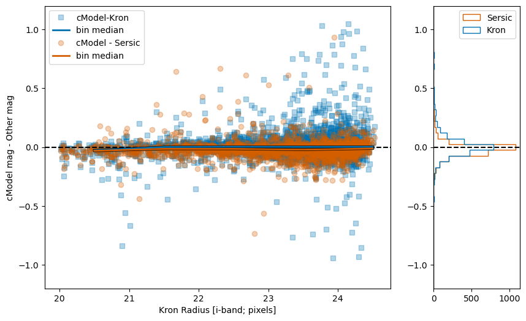

```python
fig, (ax, ax2) = plt.subplots(ncols=2, nrows=1,
                              width_ratios=[0.8, 0.2], figsize=(10, 6))

bins = np.arange(16, 27, 1)

ylims = [-1.2, 1.2]

ax.plot(cmodel_mag, (cmodel_mag - kron_mag), 's', alpha=.3,
        label='cModel-Kron', color=colors[0])
x = cmodel_mag
y = (cmodel_mag-kron_mag)
bin_mean, bin_edge, binnum = binned_statistic(x, y,
                                              statistic='median', bins=bins)
binctr = bin_edge[:-1] + (bin_edge[1:]-bin_edge[:-1]) / 2
ax.plot(binctr, bin_mean, color='k', lw=3, label=None, zorder=10)
ax.plot(binctr, bin_mean, color=colors[0], lw=2, label='bin median', zorder=11)

ax.plot(cmodel_mag, (cmodel_mag-sersic_mag), 'o', alpha=.3,
        label='cModel - Sersic', color=colors[2])

x = cmodel_mag
y = (cmodel_mag-sersic_mag)
bin_mean, bin_edge, binnum = binned_statistic(x, y,
                                              statistic='median', bins=bins)
binctr = bin_edge[:-1] + (bin_edge[1:]-bin_edge[:-1])/2
ax.plot(binctr, bin_mean, color='k', lw=3, label=None, zorder=10)
ax.plot(binctr, bin_mean, color=colors[2], lw=2, label='bin median', zorder=11)

ax.axhline(0, linestyle='--')
ax.set_xlabel('cModel Magnitude')
ax.set_ylabel('cModel mag - Sersic mag')
ax.set_ylim([-1, 1])
ax.legend()


ax2.hist((cmodel_mag-sersic_mag), orientation="horizontal",
         bins=np.linspace(ylims[0], ylims[1], 50), align='mid',
         histtype="step", color=colors[2], stacked=True, fill=False, label='Sersic')
ax2.hist((cmodel_mag-kron_mag), orientation="horizontal",
         bins=np.linspace(ylims[0], ylims[1], 50), align='mid',
         histtype="step", color=colors[0], stacked=True, fill=False, label='Kron')

ax2.set_ylim(ylims)
ax2.axhline(0, linestyle='--', color='k')
ax.axhline(0, linestyle='--', color='k')
ax.set_xlabel('Kron Radius [i-band; pixels]')
ax.set_ylabel('cModel mag - Other mag')
ax.set_ylim(ylims)

ax.legend()
ax2.legend()
```

> **Figure 5:** A figure comparing the difference between cModel and Kron magnitudes, compared to the difference between cModel and Sersic magnitudes (left panel). Generally, both Kron and Sersic the measurements are in comparable agreement with cModel. The right panel shows the histogram of magnitude differences, demonstrating that there are not systematic offsets but slightly higher scatter from Kron with respect to cModel.

Below, explore how circular aperture photometry compares to cModel. Generally, magnitudes measured using aperture photometry in the LSST pipeline are fainter than those measured from cModel, because the fixed circular aperture systematically underestimates the flux in the galaxy wings (and the lost flux increases as the intrinsic size of the galaxy increases, e.g. as traced by the Kron radius).

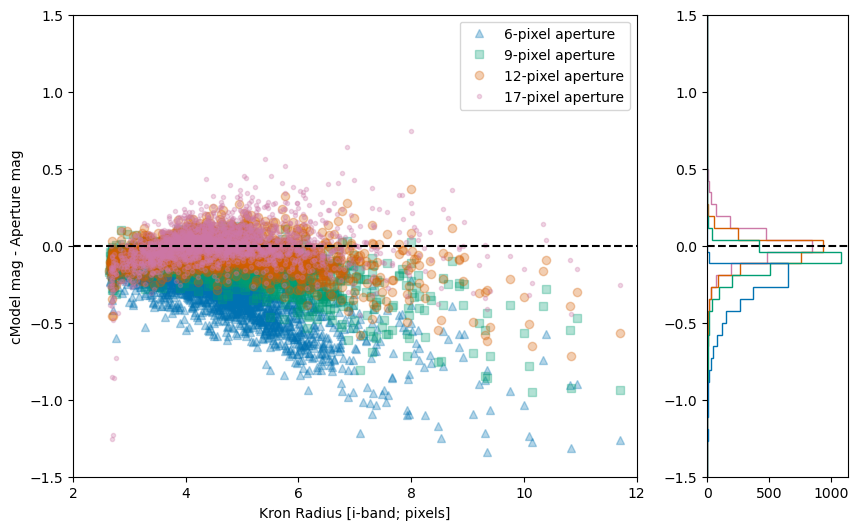

```python
fig, (ax, ax2) = plt.subplots(ncols=2, nrows=1,
                              width_ratios=[0.8, 0.2], figsize=(10, 6))

bins = np.arange(2, 15, 1)
ylims = [-1.5, 1.5]

ax.plot(i_kronRad, (cmodel_mag-ap06_mag), '^', alpha=.3,
        label='6-pixel aperture', color=colors[0])
ax.plot(i_kronRad, (cmodel_mag-ap09_mag), 's', alpha=.3,
        label='9-pixel aperture', color=colors[1])
ax.plot(i_kronRad, (cmodel_mag-ap12_mag), 'o', alpha=.3,
        label='12-pixel aperture', color=colors[2])
ax.plot(i_kronRad, (cmodel_mag-ap17_mag), '.', alpha=.3,
        label='17-pixel aperture', color=colors[3])

ax2.hist((cmodel_mag-ap17_mag), edgecolor=colors[3], orientation="horizontal",
         bins=np.linspace(ylims[0], ylims[1], 40), align='mid',
         histtype="step", stacked=True, fill=False)
ax2.hist((cmodel_mag-ap12_mag), edgecolor=colors[2], orientation="horizontal",
         bins=np.linspace(ylims[0], ylims[1], 40), align='mid',
         histtype="step", stacked=True, fill=False)
ax2.hist((cmodel_mag-ap09_mag), edgecolor=colors[1], orientation="horizontal",
         bins=np.linspace(ylims[0], ylims[1], 40), align='mid',
         histtype="step", stacked=True, fill=False)
ax2.hist((cmodel_mag-ap06_mag), edgecolor=colors[0], orientation="horizontal",
         bins=np.linspace(ylims[0], ylims[1], 40), align='mid',
         histtype="step", stacked=True, fill=False)

ax2.set_ylim(ylims)
ax.axhline(0, linestyle='--', color='k')
ax2.axhline(0, linestyle='--', color='k')
ax.set_xlabel('Kron Radius [i-band; pixels]')
ax.set_ylabel('cModel mag - Aperture mag')
ax.set_ylim(ylims)
ax.set_xlim([2, 12])
ax.legend()
```

> **Figure 6:** A comparison of the difference between cModel photometry and aperture photometry measured by the LSST pipelines for four different aperture sizes as a function of galaxy size (as measured using the Kron radius). The left panel shows the scatter plot of difference in photometry vs Kron radius, and the right panel shows a histogram of these values that demonstrate that larger aperture sizes have photometry that is closer to the cModel. The right panel shows histograms of the data in the left panel, where the colors indicate for the same data in each panel.

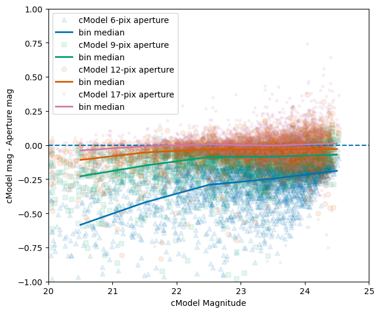

```python
fig, ax = plt.subplots(ncols=1, nrows=1, figsize=(7, 6))
ylims = [-1.2, 1.2]
bins = np.arange(16, 27, 1)

ax.plot(cmodel_mag, (cmodel_mag-ap06_mag), '^', alpha=.1,
        label='cModel 6-pix aperture', color=colors[0])
x = cmodel_mag
y = (cmodel_mag-ap06_mag)
bin_mean, bin_edge, binnum = binned_statistic(x, y,
                                              statistic='median', bins=bins)
binctr = bin_edge[:-1] + (bin_edge[1:]-bin_edge[:-1])/2
ax.plot(binctr, bin_mean, color=colors[0], lw=2, label='bin median', zorder=10)

ax.plot(cmodel_mag, (cmodel_mag-ap09_mag), 's', alpha=.1,
        label='cModel 9-pix aperture', color=colors[1])
x = cmodel_mag
y = (cmodel_mag-ap09_mag)
bin_mean, bin_edge, binnum = binned_statistic(x, y,
                                              statistic='median', bins=bins)
binctr = bin_edge[:-1] + (bin_edge[1:]-bin_edge[:-1])/2
ax.plot(binctr, bin_mean, color=colors[1], lw=2,
        label='bin median', zorder=10)

ax.plot(cmodel_mag, (cmodel_mag-ap12_mag), 'o', alpha=.1,
        label='cModel 12-pix aperture', color=colors[2])
x = cmodel_mag
y = (cmodel_mag-ap12_mag)
bin_mean, bin_edge, binnum = binned_statistic(x, y,
                                              statistic='median', bins=bins)
binctr = bin_edge[:-1] + (bin_edge[1:]-bin_edge[:-1])/2
ax.plot(binctr, bin_mean, color=colors[2], lw=2,
        label='bin median', zorder=10)

ax.plot(cmodel_mag, (cmodel_mag-ap17_mag), '.', alpha=.1,
        label='cModel 17-pix aperture', color=colors[3])
x = cmodel_mag
y = (cmodel_mag-ap17_mag)
bin_mean, bin_edge, binnum = binned_statistic(x, y,
                                              statistic='median', bins=bins)
binctr = bin_edge[:-1] + (bin_edge[1:]-bin_edge[:-1])/2
ax.plot(binctr, bin_mean, color=colors[3], lw=2,
        label='bin median', zorder=10)

ax.axhline(0, linestyle='--')
ax.set_xlabel('cModel Magnitude')
ax.set_ylabel('cModel mag - Aperture mag')
ax.set_ylim([-1, 1])
ax.set_xlim([20, 25])
ax.legend()
```

> **Figure 7:** A similar comparison of the difference between cModel photometry and aperture photometry measured by the LSST pipelines for four different aperture sizes, this time as a function of cModel magnitude. Running median is included.

These two figures show that the aperture photometry typically under-estimates the flux relative to the total flux estimated using cModel. As expected, there is a general trend for larger apertures to get closer to the total flux from cModel for large galaxies (i.e. whose Kron Radius is larger). There is also a general trend for the aperture photometry to be less discrepant at fainter magnitudes, since faint galaxies tend to be small.

### 4.2. Application of aperture photometry: radial profile

A science application for the aperture photometry is easy visualization of the radial profile of galaxies. In the cell below, make this plot for both a large galaxy (first) and a smaller galaxy of similar brightness (second). The query looks for bright galaxies whose `cModel` magnitude ~ 20 ABmag. Dividing the aperture flux by the surface area of the aperture yields the surface brightness, which can be plotted as a function of radius from the center of the galaxy to compare radial light profiles.

```
large galaxy mag =  20.943514251708983  small galaxy mag =  20.850939893722533
```

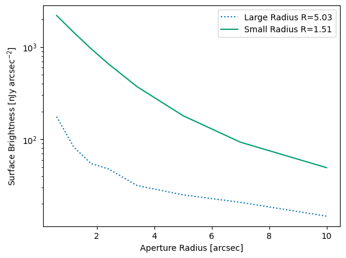

```python
wh = np.where((tab['i_kronRad'] > 20) & (cmodel_mag > 20)
              & (cmodel_mag < 21.5))[0]

indx = 0
arcsec_per_pix = 0.2

rad = np.array([3, 6, 9, 12, 17, 25, 35, 50]) * arcsec_per_pix
area = np.pi * rad**2
profile = np.array([tab['i_ap03Flux'][wh][indx], tab['i_ap06Flux'][wh][indx],
                    tab['i_ap09Flux'][wh][indx], tab['i_ap12Flux'][wh][indx],
                    tab['i_ap17Flux'][wh][indx], tab['i_ap25Flux'][wh][indx],
                    tab['i_ap35Flux'][wh][indx], tab['i_ap50Flux'][wh][indx]]) / area

plt.plot(rad, profile, linestyle=':',
         label='Large Radius R='
         + str(np.round(i_kronRad[wh][indx]*arcsec_per_pix, 2)))
plt.xlabel('Aperture Radius [arcsec]')
plt.ylabel(r'Surface Brightness [nJy arcsec$^{-2}$]')

wh2 = np.where((tab['i_kronRad'] < 8) & (tab['i_kronRad'] > 5)
               & (cmodel_mag > 20) & (cmodel_mag < 21.5))[0]

indx = 0
print("large galaxy mag = ", cmodel_mag[wh][indx], " small galaxy mag = ", cmodel_mag[wh2][indx])

profile = np.array([tab['i_ap03Flux'][wh2][indx], tab['i_ap06Flux'][wh2][indx],
                    tab['i_ap09Flux'][wh2][indx], tab['i_ap12Flux'][wh2][indx],
                    tab['i_ap17Flux'][wh2][indx], tab['i_ap25Flux'][wh2][indx],
                    tab['i_ap35Flux'][wh2][indx], tab['i_ap50Flux'][wh2][indx]])/area

plt.plot(rad, profile,
         label='Small Radius R='
         + str(round(i_kronRad[wh2][indx]*arcsec_per_pix, 2)))
plt.legend()
plt.yscale('log')
```

## 5. Photometry for color

This section will explore GaaP fluxes (which are optimized for measuring accurate colors between bands).

##### GaaP fluxes

These are the Gaussian-aperture-and-PSF flux that is defined in [Kuijken et al. 2008](https://ui.adsabs.harvard.edu/abs/2008A%26A...482.1053K/abstract). The main goal of this method is to measure accurate colors while accounting for the different spatial resolution between filters. This is sometimes achieved in other datasets by convolving all images to the largest PSF, but this process of PSF-matching is computationally very time consuming for large images, thus motivating GaaP as a faster alternative. It is not a measure of total flux in a filter. Several measurement apertures are available.

**Aperture**

```
<f>_gaap<ap>Flux    : GaaP flux with <ap> aperture after multiplying the seeing aperture. Forced on <f>-band.
<f>_gaap<ap>FluxErr : Uncertainty of <f>_gaap<ap>Flux.
```

Where the measurement apertures are 0.7 and 1.0 arcseconds. In the column name `<ap>` appears as `0p7` and `1p0`. Multiplying by the "seeing aperture" refers to convolving the PSF with a kernel so that the PSF is as if the seeing were 1.15 arcseconds. This has the effect of smearing the images of all filters consistently so that the colors are accurate.

For photometric redshifts, and other analysis where accurate colors are important, it is recommended to start with the GaaP fluxes with 1.0 aperture, which was found to have better overall performance compared to other aperture sizes. Experiment yourself to see how it works for your science case.

#### 5.1. Kron and GaaP comparison

In the next cell, compare the cModel instead to the Kron and GaaP measures.

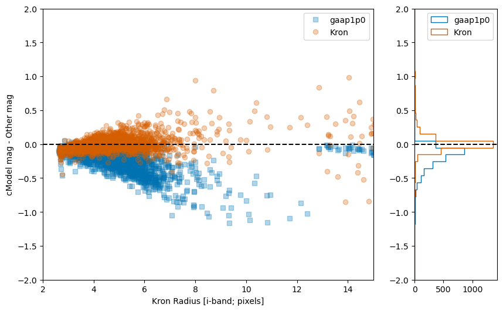

```python
fig, (ax, ax2) = plt.subplots(ncols=2, nrows=1,
                              width_ratios=[0.8, 0.2], figsize=(10, 6))
ylims = [-2, 2]

ax.plot(i_kronRad, (cmodel_mag-gaap_mag), 's', alpha=.3,
        label='gaap1p0', color=colors[0])

ax.plot(i_kronRad, (cmodel_mag-kron_mag), 'o', alpha=.3,
        label='Kron', color=colors[2])

ax2.hist((cmodel_mag-gaap_mag), orientation="horizontal",
         bins=np.linspace(ylims[0], ylims[1], 40), align='mid',
         histtype="step", color=colors[0], stacked=True, fill=False, label='gaap1p0')
ax2.hist((cmodel_mag-kron_mag), orientation="horizontal",
         bins=np.linspace(ylims[0], ylims[1], 40), align='mid',
         histtype="step", color=colors[2], stacked=True, fill=False, label='Kron')

ax2.set_ylim(ylims)
ax.axhline(0, linestyle='--', color='k')
ax2.axhline(0, linestyle='--', color='k')
ax.set_xlabel('Kron Radius [i-band; pixels]')
ax.set_ylabel('cModel mag - Other mag')
ax.set_ylim(ylims)
ax.set_xlim([2, 15])
ax.legend()
ax2.legend()
```

#### 5.2. CMD with GaaP

The earlier query in Section 2 returned signal-to-noise ratio $>20$ galaxies from a blank, "field" location (the ECDFS) and stored them in the `tab` table. These will be dominated by bluer star forming galaxies which are most common in field environments.

Add a new query near a known galaxy cluster PSZ2 G309.43-72.86 at redshift z=0.35, from the ELAIS-S1 field, and use a signal-to-noise ratio $>50$ instead of $20$.

```python
cluster_ra = 10.2082
cluster_dec = -44.1307
query = "SELECT obj.objectId, obj.coord_ra, obj.coord_dec, " + \
        "obj.detect_fromBlend, obj.detect_isIsolated, " + \
        "obj.i_blendedness, obj.i_extendedness, " + \
        "obj.i_kronFlux, obj.i_kronFluxErr, obj.i_kronRad, " + \
        "obj.i_cModelFlux, obj.i_cModelFluxErr, obj.i_gaap1p0Flux, " + \
        "obj.r_gaap1p0Flux, " + \
        "obj.i_kronFlux_flag, obj.i_cModel_flag " + \
        "FROM dp2.Object AS obj " + \
        "WHERE (obj.i_cModelFlux/obj.i_cModelFluxErr > 50) AND " + \
        "(obj.i_extendedness = 1) AND " + \
        "(obj.i_kronFlux_flag = 0) AND (obj.i_cModel_flag = 0) AND " + \
        "CONTAINS(POINT('ICRS', obj.coord_ra, obj.coord_dec), " + \
        "CIRCLE('ICRS',"+str(cluster_ra)+","+str(cluster_dec)+", 0.2)) = 1 "
```

```python
job = service.submit_job(query)
job.run()
job.wait(phases=['COMPLETED', 'ERROR'])
print('Job phase is', job.phase)
if job.phase == 'ERROR':
    job.raise_if_error()
assert job.phase == 'COMPLETED'
tab2 = job.fetch_result().to_table()
```

```
Job phase is COMPLETED
```

First, calculate the magnitudes of galaxies in the 'field' location. Then, calculate the magnitudes for the other filters near the galaxy cluster from the query performed in the cell above. This will enable plotting their colors.

> **Warning:** Like in Section 2, the following cell will produce warnings for invalid value encountered in log10, which happens if the source flux is negative. This happens for a small number of objects and since the goal of the plot is to see the distribution of the majority of sources, the warning can be safely ignored.

```python
r_field_gaap_mag = -2.50 * np.log10(tab['r_gaap1p0Flux']) + 31.4
i_field_gaap_mag = -2.50 * np.log10(tab['i_gaap1p0Flux']) + 31.4
i_field_cmodel_mag = -2.50 * np.log10(tab['i_cModelFlux']) + 31.4
i_cluster_gaap_mag = -2.50 * np.log10(tab2['i_gaap1p0Flux']) + 31.4
r_cluster_gaap_mag = -2.50 * np.log10(tab2['r_gaap1p0Flux']) + 31.4
i_cluster_cmodel_mag = -2.50 * np.log10(tab2['i_cModelFlux']) + 31.4
```

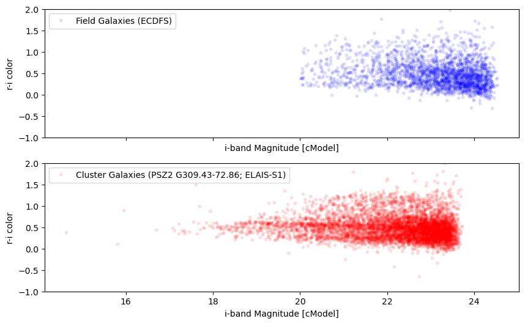

```python
fig, (ax, ax1) = plt.subplots(ncols=1, nrows=2, figsize=(10, 6), sharex=True)

ax.plot(i_field_cmodel_mag, (r_field_gaap_mag-i_field_gaap_mag),
        '.', alpha=.1, color='blue', label='Field Galaxies (ECDFS)')
ax.set_xlabel('i-band Magnitude [cModel]')
ax.set_ylabel('r-i color')
ax.set_ylim([-1, 2])
ax.legend()

ax1.plot(i_cluster_cmodel_mag, (r_cluster_gaap_mag-i_cluster_gaap_mag),
         '.', alpha=.1, color='r', label='Cluster Galaxies (PSZ2 G309.43-72.86; ELAIS-S1)')
ax1.set_xlabel('i-band Magnitude [cModel]')
ax1.set_ylabel('r-i color')
ax1.set_ylim([-1, 2])
ax1.legend()
```

> **Figure 10:** The r − i vs. i color-magnitude diagram for galaxies selected in the queries. Top panel shows the SNR$>20$ galaxies selected from in a random field that does not contain a galaxy cluster (ECDFS). The bottom panel shows the SNR$>50$ galaxies from a field with a galaxy cluster, PSZ2 G309.43-72.86. The cluster galaxies appear as a "red sequence" with red r-i colors, because the Balmer / 4000 Angstrom break spectral feature that traces older stars sits between the bands. The faint-end cutoff is different for the two subsets due to the different SNR used in the query selection.

A very nice red sequence appears from the red, old galaxies in the cluster!